# Линейная алгебра. Практическая работа №6

[🌀 Home Page](https://olgabelitskaya.github.io/README.html) [📓 Previous](https://github.com/OlgaBelitskaya/linear_algebra_practice/blob/master/work1_5.ipynb) [📓 Next](https://github.com/OlgaBelitskaya/linear_algebra_practice/blob/master/work1_7.ipynb)

### Программные средства

[LaTeX. Mathematics](https://en.wikibooks.org/wiki/LaTeX/Mathematics)

[Sage. Double Precision Complex Numbers](http://doc.sagemath.org/html/en/reference/rings_numerical/sage/rings/complex_double.html)

[Sage. Arbitrary Precision Complex Number](http://doc.sagemath.org/html/en/reference/rings_numerical/sage/rings/complex_number.html)

[Numpy. Quickstart tutorial](https://docs.scipy.org/doc/numpy/user/quickstart.html#linear-algebra)

[SymPy. Numerical evaluation](https://docs.sympy.org/latest/modules/evalf.html)

[complex function | R Documentation](https://www.rdocumentation.org/packages/base/versions/3.1.1/topics/complex)

### Конспекты лекций

[АЛГЕБРА И ГЕОМЕТРИЯ ДЛЯ СТУДЕНТОВ-ФИЗИКОВ](http://math.phys.msu.ru/data/24/Algebra_and_geometry.pdf)

[Computational Mathematics with SageMath](http://dl.lateralis.org/public/sagebook/sagebook-ba6596d.pdf)

# Комплексные числа

## 1. Действия с комплексными числами.

Сложение комплексных чисел

$(a + bi) + (c + di) = (a + c) + (b + d)i$

Вычитание комплексных чисел

$(a + bi) - (c + di) = (a - c) + (b - d)i$

Умножение комплексных чисел

$(a + bi) * (c + di) = (ac - bd) + (ad + bc)i$

Деление комплексных чисел

$\large{\frac{a + bi}{c + di} = \frac{(a + bi) * (c - di)}{(c + di) * (c - di)} = \frac{ac+ bd}{c^2 + d^2} + \frac{bc - ad}{c^2 + d^2}i}$

```python
var('a b c d');
i=ComplexField(20).0; Z1=a+b*i; Z2=c+d*i
z11,z12,z13,z14,z15=4+3*i,1+2*i,1+3*i,-10+1*i,-7+6*i
z21,z22,z23,z24,z25=\
CDF(4,3),CDF(1,2),CDF(1,3),CDF(-10,1),CDF(-7,6)
z1=-(2-3**0.5)**0.5+i*(2+3**0.5)**0.5; z2=3**0.5+i; z3=-1+i
Z1,Z2,z1,z2,z3
```

```
(a + 1.0000*I*b,
 c + 1.0000*I*d,
 -0.51764 + 1.9319*I,
 1.7320 + 1.0000*I,
 -1.0000 + 1.0000*I)
```

```python
Z1+Z2,Z1-Z2,(Z1*Z2).expand(),(Z1/Z2).expand()
```

```
(a + 1.0000*I*b + c + 1.0000*I*d,
 a + 1.0000*I*b - c - 1.0000*I*d,
 a*c + 1.0000*I*b*c + 1.0000*I*a*d - 1.0000*b*d,
 a/(c + 1.0000*I*d) + 1.0000*I*b/(c + 1.0000*I*d))
```

$$\newcommand{\Bold}[1]{\mathbf{#1}}\left[\verb|z1+z2|, \verb|z2-z3|, \verb|z1*z4|, \verb|z2/z5|\right]$$

$$\newcommand{\Bold}[1]{\mathbf{#1}}\left[5.0000 + 5.0000i, -1.0000i, -43.000 - 26.000i, 0.058823 - 0.23529i\right]$$

$$\newcommand{\Bold}[1]{\mathbf{#1}}\left[5.0 + 5.0i, -1.0i, -43.0 - 26.0i, 0.0588235294117647 - 0.2352941176470588i\right]$$

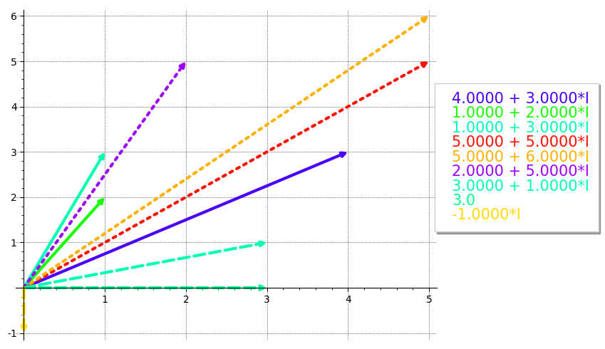

```python
pretty_print([r'z1+z2',r'z2-z3',r'z1*z4',r'z2/z5'])
pretty_print([z11+z12,z12-z13,z11*z14,z12/z15])
pretty_print([z21+z22,z22-z23,z21*z24,z22/z25])
g=Graphics(); ls=3*['-']+3*[':']+3*['--']
Z=[z11,z12,z13,z11+z12,z11+z13,z12+z13,
   z11-z12,z11-z13,z12-z13]
for k in [0..8]:
    g+=arrow2d((0,0),(Z[k].real(),Z[k].imag()),
               width=3,arrowsize=2,linestyle=ls[k],
               rgbcolor=hue(abs(Z[k])/7),
               legend_color=hue(abs(Z[k])/7),
               legend_label=Z[k])
g.set_legend_options(bbox_to_anchor=(1.3,0.1,0.1,0.7),
                     font_size=15)
g.show(gridlines=True,figsize=(9,5))
```

```python
import numpy,sympy,mpmath
NZ=numpy.array([4+3j,1+2j,1+3j,
                -10+1j,-7+6j])
nz=numpy.array([-(2-3**0.5)**0.5+(2+3**0.5)**0.5*1j,
                3**0.5+1j,-1+1j])
SZ=[complex(4+3*sympy.I),complex(1+2*sympy.I),
    complex(1+3*sympy.I),complex(-10+1*sympy.I),
    complex(-7+6*sympy.I)]
sz=[complex(-sympy.sqrt(2-sympy.sqrt(3))+\
            sympy.sqrt(2+sympy.sqrt(3))*sympy.I),
    complex(sympy.sqrt(3)+1*sympy.I),
    complex(-1+1*sympy.I)]
```

```python
print(NZ[0]+NZ[1],NZ[1]-NZ[2],
      NZ[0]*NZ[3],NZ[1]/NZ[4])
[SZ[0]+SZ[1],SZ[1]-SZ[2],
 SZ[0]*SZ[3],SZ[1]/SZ[4]]
```

```
((5+5j), -1j, (-43-26j), (0.0588235294117647-0.23529411764705882j))
```

```
[(5+5j), -1j, (-43-26j), (0.0588235294117647-0.23529411764705885j)]
```

```python
%%r
library(Matrix)
Z<-c(complex(real=4,imaginary=3),
     complex(real=1,imaginary=2),
     complex(real=1,imaginary=3),
     complex(real=-10,imaginary=1),
     complex(real=-7,imaginary=6))
z<-c(complex(real=-sqrt(2-sqrt(3)),
             imaginary=sqrt(2+sqrt(3))),
     complex(real=sqrt(3),imaginary=1),
     complex(real=-1,imaginary=1))
list(Z,z)
```

```
[[1]]
[1]   4+3i   1+2i   1+3i -10+1i  -7+6i

[[2]]
[1] -0.517638+1.931852i  1.732051+1.000000i -1.000000+1.000000i
```

```python
%%r
c(Z[1]+Z[2],Z[2]-Z[3],Z[1]*Z[4],Z[2]/Z[5])
```

```
[1]   5.0000000+ 5.0000000i   0.0000000- 1.0000000i -43.0000000-26.0000000i
[4]   0.0588235- 0.2352941i
```

## 2. Тригонометрическая форма.

Возведение комплексного числа в степень в тригонометрической форме:

$z^k = [r * (\cos \varphi + i \sin \varphi)]^n = r^n * [\cos(n\varphi) + i \sin(n\varphi) ]$

Умножение комплексных чисел в тригонометрической форме:

$z_1 * z_2 = r_1 * (\cos \varphi_1 + i \sin \varphi_1) * r_2 * (\cos \varphi_2 + i \sin \varphi_2) = r_1r_2 * [\cos(\varphi_1 + \varphi_2) + i \sin(\varphi_1 + \varphi_2) ]$

Деление комплексных чисел в тригонометрической форме:

$\frac{z_1}{z_2} = \frac{r_1 * (\cos \varphi_1 + i \sin \varphi_1)} { r_2 * (\cos \varphi_2 + i \sin \varphi_2)} = \frac {r_1}{r_2} * [\cos(\varphi_1 - \varphi_2) + i \sin(\varphi_1 - \varphi_2) ]$

Извлечение корня из комплексного числа в тригонометрической форме:

$\sqrt[n] {z} = \sqrt[n] {r * (\cos \varphi + i \sin \varphi)} = \sqrt[n]{r} * \bigg(\cos \frac{\varphi + 2\pi m}{n} + i \sin \frac{\varphi + 2\pi m}{n} \bigg), \ m = 0, 1, ..., n-1$

$\mathscr{Z_1 = -\sqrt{2 - \sqrt{3}} + \sqrt{2 + \sqrt{3}} i; \ Z_2 = \sqrt{3} + i; \ Z_3 = -1 + i}$

```python
print([z1,abs(z1),arg(z1)])
# [polar form, exponential form]
[abs(z1)*(cos(arg(z1))+i*sin(arg(z1))),
 abs(z1)*e^(i*(arg(z1)))]
```

```
[-0.51764 + 1.9319*I, 2.0000, 1.8326]
```

```
[-0.51764 + 1.9319*I, -0.51764 + 1.9319*I]
```

```python
nr=numpy.sqrt(numpy.real(nz)**2+numpy.imag(nz)**2)
nt=numpy.arctan2(numpy.imag(nz),numpy.real(nz))
# [polar form, exponential form]
[nr[0]*(numpy.cos(nt[0])+numpy.sin(nt[0])*1j),
 nr[0]*numpy.exp(1j*(nt[0]))]
```

```
[(-0.5176380902050417+1.9318516525781366j),
 (-0.5176380902050417+1.9318516525781366j)]
```

```python
print(mpmath.polar(sz[0]))
# [polar form, exponential form]
[mpmath.fabs(sz[0])*(mpmath.cos(mpmath.arg(sz[0]))+\
 mpmath.sin(mpmath.arg(sz[0]))*sympy.I),
 mpmath.fabs(sz[0])*mpmath.exp(mpmath.arg(sz[0])*sympy.I)]
```

```
(mpf('2.0'), mpf('1.8325957145940461'))
```

```
[mpc(real='-0.5176380902050417', imag='1.9318516525781366'),
 mpc(real='-0.5176380902050417', imag='1.9318516525781366')]
```

```python
%%r
cart2pol<-function(z) {c(Mod(z), Arg(z))}
print(cart2pol(z[1]))
# polar form, exponential form
c(Mod(z[1])*(cos(Arg(z[1]))+sin(Arg(z[1]))*sqrt(as.complex(-1))),
  Mod(z[1])*exp(Arg(z[1])*sqrt(as.complex(-1))))
```

```
[1] 2.000000 1.832596
[1] -0.517638+1.931852i -0.517638+1.931852i
```

$\mathbb{Z_1^{10} * Z_2^6, \ Z_2^{15} \ / \ Z_3^{27}, \sqrt[4] {Z_1}}$

```python
print(z1**10*z2**6,
      abs(z1)**10*abs(z2)**6*(cos(10*arg(z1)+6*arg(z2))+\
                              i*sin(10*arg(z1)+6*arg(z2))))
print(z2**15/z3**27,
      abs(z2)**15/abs(z3)**27*(cos(15*arg(z2)-27*arg(z3))+\
                               i*sin(15*arg(z2)-27*arg(z3))))
r=[abs(z1)**(1/4)*(cos((arg(z1)+2*pi.n()*j)/4)+\
                   i*sin((arg(z1)+2*pi.n()*j)/4))
   for j in[0..3]]
print(z1**(1/4)); print(r)
```

```
(-56756. + 32768.*I, -56756. + 32767.*I)
(2.0000 + 2.0000*I, 1.9999 + 2.0000*I)
1.0666 + 0.52597*I
[1.0666 + 0.52597*I, -0.52597 + 1.0666*I, -1.0666 - 0.52597*I, 0.52597 - 1.0666*I]
```

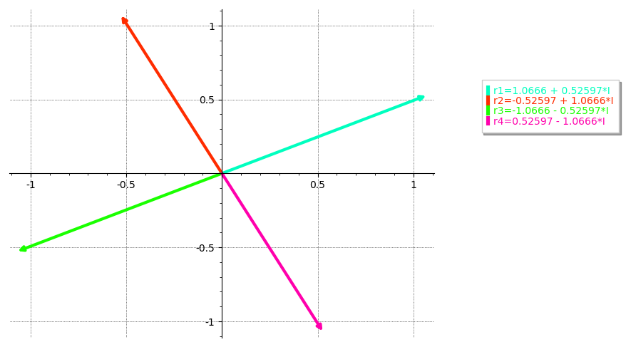

```python
g=Graphics()
for j in [0..3]:
    g+=arrow2d((0,0),(r[j].real(),r[j].imag()),
               width=3,arrowsize=2,rgbcolor=hue(arg(r[j])),
               legend_color=hue(arg(r[j])),
               legend_label='r'+str(j+1)+'='+str(r[j]))
g.set_legend_options(bbox_to_anchor=(1.1,0.1,0.1,0.7))
g.show(gridlines=True,figsize=(9,5))
```

```python
print(nz[0]**10*nz[1]**6,
      nr[0]**10*nr[1]**6*(numpy.cos(10*nt[0]+6*nt[1])+\
                          numpy.sin(10*nt[0]+6*nt[1])*1j))
print(nz[1]**15/nz[2]**27,
      nr[1]**15/nr[2]**27*(numpy.cos(15*nt[1]-27*nt[2])+\
                           numpy.sin(15*nt[1]-27*nt[2])*1j))
print(nz[0]**(1/4))
[nr[0]**(1/4)*(numpy.cos((nt[0]+2*numpy.pi*k)/4)+\
               numpy.sin((nt[0]+2*numpy.pi*k)/4)*1j)
 for k in range(4)]
```

```
((-56755.840862417+32767.999999999975j), (-56755.840862416924+32767.999999999993j))
((1.9999999999999973+1.9999999999999991j), (1.9999999999999798+2.0000000000000067j))
(1.0665674454826692+0.5259728572936707j)
```

```
[(1.0665674454826692+0.5259728572936707j),
 (-0.5259728572936705+1.0665674454826695j),
 (-1.0665674454826695-0.5259728572936705j),
 (0.5259728572936705-1.0665674454826695j)]
```

```python
print([sz[0]**10*sz[1]**6,
complex(mpmath.fabs(sz[0])**10*mpmath.fabs(sz[1])**6*\
(mpmath.cos(10*mpmath.arg(sz[0])+6*mpmath.arg(sz[1]))+\
mpmath.sin(10*mpmath.arg(sz[0])+6*mpmath.arg(sz[1]))*sympy.I))])
print([sz[1]**15/sz[2]**27,
complex(mpmath.fabs(sz[1])**15/mpmath.fabs(sz[2])**27*\
(mpmath.cos(15*mpmath.arg(sz[1])-27*mpmath.arg(sz[2]))+\
mpmath.sin(15*mpmath.arg(sz[1])-27*mpmath.arg(sz[2]))*sympy.I))])
print(sz[0]**(1/4))
[complex(mpmath.fabs(sz[0])**(1/4)*\
 (mpmath.cos((mpmath.arg(sz[0])+2*mpmath.pi*k)/4)+\
 mpmath.sin((mpmath.arg(sz[0])+2*mpmath.pi*k)/4)*sympy.I))
 for k in range(4)]
```

```
[(-56755.840862416946+32768.00000000001j), (-56755.84086241696+32768.000000000015j)]
[(1.9999999999999973+1.9999999999999991j), (1.999999999999983+2.0000000000000098j)]
(1.06656744548+0.525972857294j)
```

```
[(1.0665674454826692+0.5259728572936707j),
 (-0.5259728572936705+1.0665674454826695j),
 (-1.0665674454826695-0.5259728572936705j),
 (0.5259728572936704-1.0665674454826695j)]
```

```python
%%r
print(c((z[1]^10)*(z[2]^6),(z[2]^15)/(z[3]^27),z[1]^(1/4)))
print(Mod(z[1])^10*Mod(z[2])^6*(cos(10*Arg(z[1])+6*Arg(z[2]))+
      sin(10*Arg(z[1])+6*Arg(z[2]))*sqrt(as.complex(-1))))
print(Mod(z[2])^15/Mod(z[3])^27*(cos(15*Arg(z[2])-27*Arg(z[3]))+
      sin(15*Arg(z[2])-27*Arg(z[3]))*sqrt(as.complex(-1))))
complex_k_root_n<-function(z,k,n){
    Mod(z)^(1/k)*(cos((Arg(z)+2*pi*(n-1))/4)+
                  sin((Arg(z)+2*pi*(n-1))/4)*sqrt(as.complex(-1)))}
c(complex_k_root_n(z[1],4,1),
  complex_k_root_n(z[1],4,2),
  complex_k_root_n(z[1],4,3),
  complex_k_root_n(z[1],4,4))
```

```
[1] -5.675584e+04+3.27680e+04i  2.000000e+00+2.00000e+00i
[3]  1.066567e+00+5.25973e-01i
[1] -56755.84+32768i
[1] 2+2i
[1]  1.066567+0.525973i -0.525973+1.066567i -1.066567-0.525973i
[4]  0.525973-1.066567i
```

## 3. Задание

Задать пару произвольных комплексных чисел,

выполнить сложение, вычитание, деление, возведение в степень и извлечение корня,

используя SageMath, Python, R.